# Align stock price forecast

# Prophet

Find best hyperparameters using grid serach and expanding window cross-validation

```python
def prophet_model_init(params):

    m = fp.Prophet(**params, yearly_seasonality = False, weekly_seasonality = False)
    m.add_regressor("fedfunds")
    m.add_regressor("unrate")

    return m
```

```python
def prophet_cv_score(model):

    model.fit(train_with_exogenous)
    cv_results = cross_validation(model, initial='384 days', period='40 days', horizon = '40 days', parallel="processes")
    df_p = performance_metrics(cv_results, rolling_window=1)
    return df_p.loc[0, 'mape']
```

```python
prophet_grid_search = GridSearch(
    all_params={
        'changepoint_prior_scale': [0.005, 0.01, 0.05, 0.25],
        'n_changepoints': [10, 25, 50],
        'changepoint_range': [0.7, 0.8, 0.9, 0.95]
    },
    model_initializer=prophet_model_init,
    calculate_score=prophet_cv_score
)
```

```python
prophet_grid_search.search()
```

```
11:49:31 - cmdstanpy - INFO - Chain [1] start processing
11:49:32 - cmdstanpy - INFO - Chain [1] done processing
11:49:43 - cmdstanpy - INFO - Chain [1] start processing
```

```
Iteration: 1 of 48
	Params: {'changepoint_prior_scale': 0.005, 'n_changepoints': 10, 'changepoint_range': 0.7}
	Score: 0.09867920365590124
```

```
11:49:43 - cmdstanpy - INFO - Chain [1] done processing
11:49:46 - cmdstanpy - INFO - Chain [1] start processing
11:49:46 - cmdstanpy - INFO - Chain [1] done processing
```

```
Iteration: 2 of 48
	Params: {'changepoint_prior_scale': 0.005, 'n_changepoints': 10, 'changepoint_range': 0.8}
	Score: 0.10085218035164248
```

```
11:49:48 - cmdstanpy - INFO - Chain [1] start processing
11:49:48 - cmdstanpy - INFO - Chain [1] done processing
```

```
Iteration: 3 of 48
	Params: {'changepoint_prior_scale': 0.005, 'n_changepoints': 10, 'changepoint_range': 0.9}
	Score: 0.10538192059935783
```

```
11:49:51 - cmdstanpy - INFO - Chain [1] start processing
11:49:51 - cmdstanpy - INFO - Chain [1] done processing
```

```
Iteration: 4 of 48
	Params: {'changepoint_prior_scale': 0.005, 'n_changepoints': 10, 'changepoint_range': 0.95}
	Score: 0.10505486450256811
```

```
11:49:53 - cmdstanpy - INFO - Chain [1] start processing
11:49:53 - cmdstanpy - INFO - Chain [1] done processing
```

```
Iteration: 5 of 48
	Params: {'changepoint_prior_scale': 0.005, 'n_changepoints': 25, 'changepoint_range': 0.7}
	Score: 0.10028321439510704
```

```
11:49:56 - cmdstanpy - INFO - Chain [1] start processing
11:49:56 - cmdstanpy - INFO - Chain [1] done processing
```

```
Iteration: 6 of 48
	Params: {'changepoint_prior_scale': 0.005, 'n_changepoints': 25, 'changepoint_range': 0.8}
	Score: 0.10605758092882009
```

```
11:49:58 - cmdstanpy - INFO - Chain [1] start processing
11:49:58 - cmdstanpy - INFO - Chain [1] done processing
```

```
Iteration: 7 of 48
	Params: {'changepoint_prior_scale': 0.005, 'n_changepoints': 25, 'changepoint_range': 0.9}
	Score: 0.10758962492104988
```

```
11:50:01 - cmdstanpy - INFO - Chain [1] start processing
11:50:01 - cmdstanpy - INFO - Chain [1] done processing
```

```
Iteration: 8 of 48
	Params: {'changepoint_prior_scale': 0.005, 'n_changepoints': 25, 'changepoint_range': 0.95}
	Score: 0.10308533509066446
```

```
11:50:03 - cmdstanpy - INFO - Chain [1] start processing
```

```
Iteration: 9 of 48
	Params: {'changepoint_prior_scale': 0.005, 'n_changepoints': 50, 'changepoint_range': 0.7}
	Score: 0.10403590207056335
```

```
11:50:03 - cmdstanpy - INFO - Chain [1] done processing
11:50:06 - cmdstanpy - INFO - Chain [1] start processing
11:50:06 - cmdstanpy - INFO - Chain [1] done processing
```

```
Iteration: 10 of 48
	Params: {'changepoint_prior_scale': 0.005, 'n_changepoints': 50, 'changepoint_range': 0.8}
	Score: 0.10595178128848118
```

```
11:50:08 - cmdstanpy - INFO - Chain [1] start processing
11:50:08 - cmdstanpy - INFO - Chain [1] done processing
```

```
Iteration: 11 of 48
	Params: {'changepoint_prior_scale': 0.005, 'n_changepoints': 50, 'changepoint_range': 0.9}
	Score: 0.10601585922817566
```

```
11:50:11 - cmdstanpy - INFO - Chain [1] start processing
11:50:11 - cmdstanpy - INFO - Chain [1] done processing
```

```
Iteration: 12 of 48
	Params: {'changepoint_prior_scale': 0.005, 'n_changepoints': 50, 'changepoint_range': 0.95}
	Score: 0.101543154534158
```

```
11:50:13 - cmdstanpy - INFO - Chain [1] start processing
11:50:13 - cmdstanpy - INFO - Chain [1] done processing
```

```
Iteration: 13 of 48
	Params: {'changepoint_prior_scale': 0.01, 'n_changepoints': 10, 'changepoint_range': 0.7}
	Score: 0.09112810662254378
```

```
11:50:16 - cmdstanpy - INFO - Chain [1] start processing
11:50:16 - cmdstanpy - INFO - Chain [1] done processing
```

```
Iteration: 14 of 48
	Params: {'changepoint_prior_scale': 0.01, 'n_changepoints': 10, 'changepoint_range': 0.8}
	Score: 0.09682238553317196
```

```
11:50:18 - cmdstanpy - INFO - Chain [1] start processing
11:50:18 - cmdstanpy - INFO - Chain [1] done processing
```

```
Iteration: 15 of 48
	Params: {'changepoint_prior_scale': 0.01, 'n_changepoints': 10, 'changepoint_range': 0.9}
	Score: 0.09200065446375538
```

```
11:50:21 - cmdstanpy - INFO - Chain [1] start processing
11:50:21 - cmdstanpy - INFO - Chain [1] done processing
```

```
Iteration: 16 of 48
	Params: {'changepoint_prior_scale': 0.01, 'n_changepoints': 10, 'changepoint_range': 0.95}
	Score: 0.0933709368645572
```

```
11:50:23 - cmdstanpy - INFO - Chain [1] start processing
11:50:23 - cmdstanpy - INFO - Chain [1] done processing
```

```
Iteration: 17 of 48
	Params: {'changepoint_prior_scale': 0.01, 'n_changepoints': 25, 'changepoint_range': 0.7}
	Score: 0.09277302999425979
```

```
11:50:25 - cmdstanpy - INFO - Chain [1] start processing
11:50:26 - cmdstanpy - INFO - Chain [1] done processing
```

```
Iteration: 18 of 48
	Params: {'changepoint_prior_scale': 0.01, 'n_changepoints': 25, 'changepoint_range': 0.8}
	Score: 0.09481525657015005
```

```
11:50:28 - cmdstanpy - INFO - Chain [1] start processing
11:50:28 - cmdstanpy - INFO - Chain [1] done processing
```

```
Iteration: 19 of 48
	Params: {'changepoint_prior_scale': 0.01, 'n_changepoints': 25, 'changepoint_range': 0.9}
	Score: 0.09140544821821338
```

```
11:50:31 - cmdstanpy - INFO - Chain [1] start processing
```

```
Iteration: 20 of 48
	Params: {'changepoint_prior_scale': 0.01, 'n_changepoints': 25, 'changepoint_range': 0.95}
	Score: 0.09539501070882314
```

```
11:50:31 - cmdstanpy - INFO - Chain [1] done processing
11:50:33 - cmdstanpy - INFO - Chain [1] start processing
11:50:33 - cmdstanpy - INFO - Chain [1] done processing
```

```
Iteration: 21 of 48
	Params: {'changepoint_prior_scale': 0.01, 'n_changepoints': 50, 'changepoint_range': 0.7}
	Score: 0.09426223263848707
```

```
11:50:36 - cmdstanpy - INFO - Chain [1] start processing
11:50:36 - cmdstanpy - INFO - Chain [1] done processing
```

```
Iteration: 22 of 48
	Params: {'changepoint_prior_scale': 0.01, 'n_changepoints': 50, 'changepoint_range': 0.8}
	Score: 0.09055904557240042
```

```
11:50:38 - cmdstanpy - INFO - Chain [1] start processing
```

```
Iteration: 23 of 48
	Params: {'changepoint_prior_scale': 0.01, 'n_changepoints': 50, 'changepoint_range': 0.9}
	Score: 0.09020965051642024
```

```
11:50:38 - cmdstanpy - INFO - Chain [1] done processing
11:50:41 - cmdstanpy - INFO - Chain [1] start processing
```

```
Iteration: 24 of 48
	Params: {'changepoint_prior_scale': 0.01, 'n_changepoints': 50, 'changepoint_range': 0.95}
	Score: 0.09292900823491032
```

```
11:50:41 - cmdstanpy - INFO - Chain [1] done processing
11:50:43 - cmdstanpy - INFO - Chain [1] start processing
```

```
Iteration: 25 of 48
	Params: {'changepoint_prior_scale': 0.05, 'n_changepoints': 10, 'changepoint_range': 0.7}
	Score: 0.18341409907098266
```

```
11:50:43 - cmdstanpy - INFO - Chain [1] done processing
11:50:46 - cmdstanpy - INFO - Chain [1] start processing
```

```
Iteration: 26 of 48
	Params: {'changepoint_prior_scale': 0.05, 'n_changepoints': 10, 'changepoint_range': 0.8}
	Score: 0.12631723044172816
```

```
11:50:46 - cmdstanpy - INFO - Chain [1] done processing
11:50:48 - cmdstanpy - INFO - Chain [1] start processing
```

```
Iteration: 27 of 48
	Params: {'changepoint_prior_scale': 0.05, 'n_changepoints': 10, 'changepoint_range': 0.9}
	Score: 0.10929256385848943
```

```
11:50:48 - cmdstanpy - INFO - Chain [1] done processing
11:50:51 - cmdstanpy - INFO - Chain [1] start processing
```

```
Iteration: 28 of 48
	Params: {'changepoint_prior_scale': 0.05, 'n_changepoints': 10, 'changepoint_range': 0.95}
	Score: 0.10437108591375681
```

```
11:50:51 - cmdstanpy - INFO - Chain [1] done processing
11:50:54 - cmdstanpy - INFO - Chain [1] start processing
```

```
Iteration: 29 of 48
	Params: {'changepoint_prior_scale': 0.05, 'n_changepoints': 25, 'changepoint_range': 0.7}
	Score: 0.17768818582255716
```

```
11:50:54 - cmdstanpy - INFO - Chain [1] done processing
11:50:56 - cmdstanpy - INFO - Chain [1] start processing
```

```
Iteration: 30 of 48
	Params: {'changepoint_prior_scale': 0.05, 'n_changepoints': 25, 'changepoint_range': 0.8}
	Score: 0.12314237032509567
```

```
11:50:56 - cmdstanpy - INFO - Chain [1] done processing
11:50:59 - cmdstanpy - INFO - Chain [1] start processing
```

```
Iteration: 31 of 48
	Params: {'changepoint_prior_scale': 0.05, 'n_changepoints': 25, 'changepoint_range': 0.9}
	Score: 0.11113095328870995
```

```
11:50:59 - cmdstanpy - INFO - Chain [1] done processing
11:51:02 - cmdstanpy - INFO - Chain [1] start processing
```

```
Iteration: 32 of 48
	Params: {'changepoint_prior_scale': 0.05, 'n_changepoints': 25, 'changepoint_range': 0.95}
	Score: 0.11317646807822102
```

```
11:51:02 - cmdstanpy - INFO - Chain [1] done processing
11:51:04 - cmdstanpy - INFO - Chain [1] start processing
```

```
Iteration: 33 of 48
	Params: {'changepoint_prior_scale': 0.05, 'n_changepoints': 50, 'changepoint_range': 0.7}
	Score: 0.17715143670030659
```

```
11:51:04 - cmdstanpy - INFO - Chain [1] done processing
11:51:07 - cmdstanpy - INFO - Chain [1] start processing
```

```
Iteration: 34 of 48
	Params: {'changepoint_prior_scale': 0.05, 'n_changepoints': 50, 'changepoint_range': 0.8}
	Score: 0.12384917423867585
```

```
11:51:07 - cmdstanpy - INFO - Chain [1] done processing
11:51:10 - cmdstanpy - INFO - Chain [1] start processing
```

```
Iteration: 35 of 48
	Params: {'changepoint_prior_scale': 0.05, 'n_changepoints': 50, 'changepoint_range': 0.9}
	Score: 0.11059620211020964
```

```
11:51:10 - cmdstanpy - INFO - Chain [1] done processing
11:51:13 - cmdstanpy - INFO - Chain [1] start processing
```

```
Iteration: 36 of 48
	Params: {'changepoint_prior_scale': 0.05, 'n_changepoints': 50, 'changepoint_range': 0.95}
	Score: 0.10879234466120095
```

```
11:51:13 - cmdstanpy - INFO - Chain [1] done processing
11:51:15 - cmdstanpy - INFO - Chain [1] start processing
```

```
Iteration: 37 of 48
	Params: {'changepoint_prior_scale': 0.25, 'n_changepoints': 10, 'changepoint_range': 0.7}
	Score: 0.16140650428426712
```

```
11:51:15 - cmdstanpy - INFO - Chain [1] done processing
11:51:15 - cmdstanpy - ERROR - Chain [1] error: error during processing Operation not permitted
Optimization terminated abnormally. Falling back to Newton.
11:51:15 - cmdstanpy - INFO - Chain [1] start processing
11:51:15 - cmdstanpy - INFO - Chain [1] done processing
11:51:18 - cmdstanpy - INFO - Chain [1] start processing
```

```
Iteration: 38 of 48
	Params: {'changepoint_prior_scale': 0.25, 'n_changepoints': 10, 'changepoint_range': 0.8}
	Score: 0.11154057341750659
```

```
11:51:18 - cmdstanpy - INFO - Chain [1] done processing
11:51:18 - cmdstanpy - ERROR - Chain [1] error: error during processing Operation not permitted
Optimization terminated abnormally. Falling back to Newton.
11:51:18 - cmdstanpy - INFO - Chain [1] start processing
11:51:18 - cmdstanpy - INFO - Chain [1] done processing
11:51:21 - cmdstanpy - INFO - Chain [1] start processing
```

```
Iteration: 39 of 48
	Params: {'changepoint_prior_scale': 0.25, 'n_changepoints': 10, 'changepoint_range': 0.9}
	Score: 0.09669204664158576
```

```
11:51:21 - cmdstanpy - INFO - Chain [1] done processing
11:51:23 - cmdstanpy - INFO - Chain [1] start processing
```

```
Iteration: 40 of 48
	Params: {'changepoint_prior_scale': 0.25, 'n_changepoints': 10, 'changepoint_range': 0.95}
	Score: 0.08288246085238303
```

```
11:51:24 - cmdstanpy - INFO - Chain [1] done processing
11:51:26 - cmdstanpy - INFO - Chain [1] start processing
```

```
Iteration: 41 of 48
	Params: {'changepoint_prior_scale': 0.25, 'n_changepoints': 25, 'changepoint_range': 0.7}
	Score: 0.15778491088298047
```

```
11:51:27 - cmdstanpy - INFO - Chain [1] done processing
11:51:29 - cmdstanpy - INFO - Chain [1] start processing
```

```
Iteration: 42 of 48
	Params: {'changepoint_prior_scale': 0.25, 'n_changepoints': 25, 'changepoint_range': 0.8}
	Score: 0.11256597930137766
```

```
11:51:30 - cmdstanpy - INFO - Chain [1] done processing
11:51:33 - cmdstanpy - INFO - Chain [1] start processing
```

```
Iteration: 43 of 48
	Params: {'changepoint_prior_scale': 0.25, 'n_changepoints': 25, 'changepoint_range': 0.9}
	Score: 0.09487032370216925
```

```
11:51:33 - cmdstanpy - INFO - Chain [1] done processing
11:51:35 - cmdstanpy - INFO - Chain [1] start processing
```

```
Iteration: 44 of 48
	Params: {'changepoint_prior_scale': 0.25, 'n_changepoints': 25, 'changepoint_range': 0.95}
	Score: 0.08912826137836997
```

```
11:51:36 - cmdstanpy - INFO - Chain [1] done processing
11:51:39 - cmdstanpy - INFO - Chain [1] start processing
```

```
Iteration: 45 of 48
	Params: {'changepoint_prior_scale': 0.25, 'n_changepoints': 50, 'changepoint_range': 0.7}
	Score: 0.15888152941561323
```

```
11:51:40 - cmdstanpy - INFO - Chain [1] done processing
11:51:42 - cmdstanpy - INFO - Chain [1] start processing
```

```
Iteration: 46 of 48
	Params: {'changepoint_prior_scale': 0.25, 'n_changepoints': 50, 'changepoint_range': 0.8}
	Score: 0.11188236126187663
```

```
11:51:43 - cmdstanpy - INFO - Chain [1] done processing
11:51:46 - cmdstanpy - INFO - Chain [1] start processing
```

```
Iteration: 47 of 48
	Params: {'changepoint_prior_scale': 0.25, 'n_changepoints': 50, 'changepoint_range': 0.9}
	Score: 0.09585108257831591
```

```
11:51:46 - cmdstanpy - INFO - Chain [1] done processing
```

```
Iteration: 48 of 48
	Params: {'changepoint_prior_scale': 0.25, 'n_changepoints': 50, 'changepoint_range': 0.95}
	Score: 0.08043778786358985
Best score: 0.08043778786358985
	with params {'changepoint_prior_scale': 0.25, 'n_changepoints': 50, 'changepoint_range': 0.95}
```

```python
prophet_grid_search.display_results()
```

|  | score | changepoint_prior_scale | n_changepoints | changepoint_range |
| --- | --- | --- | --- | --- |
| 47 | 0.080438 | 0.250 | 50 | 0.95 |
| 39 | 0.082882 | 0.250 | 10 | 0.95 |
| 43 | 0.089128 | 0.250 | 25 | 0.95 |
| 22 | 0.090210 | 0.010 | 50 | 0.90 |
| 21 | 0.090559 | 0.010 | 50 | 0.80 |
| 12 | 0.091128 | 0.010 | 10 | 0.70 |
| 18 | 0.091405 | 0.010 | 25 | 0.90 |
| 14 | 0.092001 | 0.010 | 10 | 0.90 |
| 16 | 0.092773 | 0.010 | 25 | 0.70 |
| 23 | 0.092929 | 0.010 | 50 | 0.95 |
| 15 | 0.093371 | 0.010 | 10 | 0.95 |
| 20 | 0.094262 | 0.010 | 50 | 0.70 |
| 17 | 0.094815 | 0.010 | 25 | 0.80 |
| 42 | 0.094870 | 0.250 | 25 | 0.90 |
| 19 | 0.095395 | 0.010 | 25 | 0.95 |
| 46 | 0.095851 | 0.250 | 50 | 0.90 |
| 38 | 0.096692 | 0.250 | 10 | 0.90 |
| 13 | 0.096822 | 0.010 | 10 | 0.80 |
| 0 | 0.098679 | 0.005 | 10 | 0.70 |
| 4 | 0.100283 | 0.005 | 25 | 0.70 |
| 1 | 0.100852 | 0.005 | 10 | 0.80 |
| 11 | 0.101543 | 0.005 | 50 | 0.95 |
| 7 | 0.103085 | 0.005 | 25 | 0.95 |
| 8 | 0.104036 | 0.005 | 50 | 0.70 |
| 27 | 0.104371 | 0.050 | 10 | 0.95 |
| 3 | 0.105055 | 0.005 | 10 | 0.95 |
| 2 | 0.105382 | 0.005 | 10 | 0.90 |
| 9 | 0.105952 | 0.005 | 50 | 0.80 |
| 10 | 0.106016 | 0.005 | 50 | 0.90 |
| 5 | 0.106058 | 0.005 | 25 | 0.80 |
| 6 | 0.107590 | 0.005 | 25 | 0.90 |
| 35 | 0.108792 | 0.050 | 50 | 0.95 |
| 26 | 0.109293 | 0.050 | 10 | 0.90 |
| 34 | 0.110596 | 0.050 | 50 | 0.90 |
| 30 | 0.111131 | 0.050 | 25 | 0.90 |
| 37 | 0.111541 | 0.250 | 10 | 0.80 |
| 45 | 0.111882 | 0.250 | 50 | 0.80 |
| 41 | 0.112566 | 0.250 | 25 | 0.80 |
| 31 | 0.113176 | 0.050 | 25 | 0.95 |
| 29 | 0.123142 | 0.050 | 25 | 0.80 |
| 33 | 0.123849 | 0.050 | 50 | 0.80 |
| 25 | 0.126317 | 0.050 | 10 | 0.80 |
| 40 | 0.157785 | 0.250 | 25 | 0.70 |
| 44 | 0.158882 | 0.250 | 50 | 0.70 |
| 36 | 0.161407 | 0.250 | 10 | 0.70 |
| 32 | 0.177151 | 0.050 | 50 | 0.70 |
| 28 | 0.177688 | 0.050 | 25 | 0.70 |
| 24 | 0.183414 | 0.050 | 10 | 0.70 |

Let's fit the best model

```python
prophet_model = prophet_model_init(prophet_grid_search.get_best_params())

prophet_model.fit(train_with_exogenous)

future = prophet_model.make_future_dataframe(periods=len(test))

future = future.merge(
    pd.concat([
        train_with_exogenous[['ds', 'fedfunds', 'unrate']],
        future_exogenous
    ]),
    left_on='ds',
    right_on='ds'
)

forecast_prophet = prophet_model.predict(future)
```

```
11:51:49 - cmdstanpy - INFO - Chain [1] start processing
11:51:50 - cmdstanpy - INFO - Chain [1] done processing
```

Plot and analyze residuals of the model

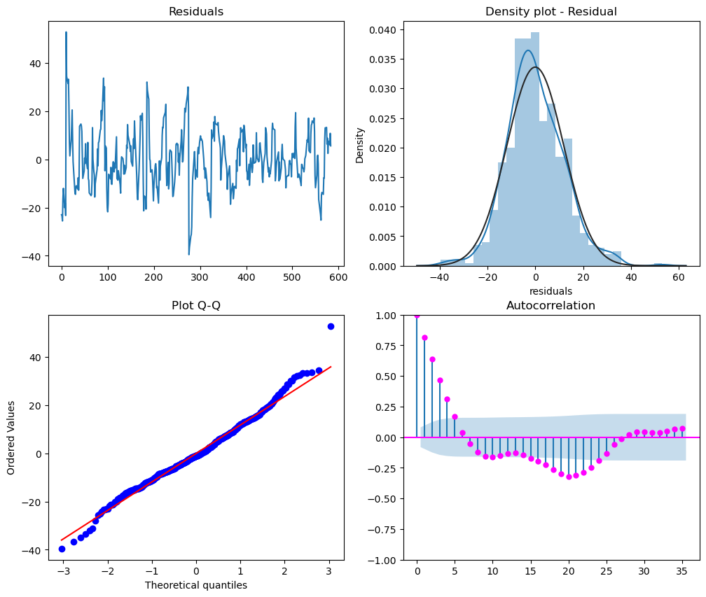

```python
fitted_forecast_prophet = pd.DataFrame(train_with_exogenous['y'] - forecast_prophet[:len(train)]['yhat'], columns=["residuals"])
plot_residuals(fitted_forecast_prophet['residuals'])
```

```python
fig = px.line(title="Closing stock prices (daily)")
fig.add_scatter(x=train['ds'], y=train['y'], mode='lines', name='train', line=dict(color='blue'))
fig.add_scatter(x=test['ds'], y=test['y'], mode='lines', name='test', line=dict(color='green'))
fig.add_scatter(x=forecast_prophet['ds'], y=forecast_prophet['yhat'], mode='lines', name='prediction', line=dict(color='red'))

fig.update_layout(template='plotly_white', width=1000, height=500)
fig.update_xaxes(title_text="date")
fig.update_yaxes(title_text="closing price")
fig.show()
```

[interactive chart not shown]

Calculate quality metric by using MAPE

```python
prophet_mape = my_mape(forecast_prophet['yhat'], test['y'])
```

```python
model_metrics_logger.info(
    f'Model name: Prophet, MAPE score: {prophet_mape}, hyperparameters: {prophet_grid_search.get_best_params()}'
)
```

```
Model name: Prophet, MAPE score: 7.206555014735036, hyperparameters: {'changepoint_prior_scale': 0.25, 'n_changepoints': 50, 'changepoint_range': 0.95}
```

# Summary

In this work, I downloaded Align's closing stock price, prepared data to work with MLForecast, NeuralForecast, and StatsForecast, and Prophet modules. Then split the data into train and test. Performed autocorrelation and stationarity analysis, came up with the conclusion that required making first-order differencing to make the time series stationary, and only one previous lag correlated with current. Then I tried five models: Linear Regression, XGBoost, ARIMA, LSTM, and Prophet, and found the best hyperparameters using grid search and cross-validation on train data. And finally fit the models on the whole training data, make predictions, and calculate the MAPE score on test data.